# Practical Machine Learning Prediction Assignment

Suchit Sharma

September 21, 2015

## Overview

Using devices such as Jawbone Up, Nike FuelBand, and Fitbit it is now possible to collect a large amount of data about personal activity relatively inexpensively. In this report, we will explore data from accelerometers on the belt, forearm, arm, and dumbell of 6 participants and predict the manner in which they did the exercise.. They were asked to perform barbell lifts correctly and incorrectly in 5 different ways. We will also use the prediction model to predict 20 different test cases in data provided by [Groupware](http://groupware.les.inf.puc-rio.br/har)

## Loading Data

```r
# Loading needed libraries
library(caret)
library(randomForest)
training <- read.csv("pml-training.csv", na.strings = c("", "NA", "NULL"))
testing  <- read.csv("pml-testing.csv",  na.strings = c("", "NA", "NULL"))

# Removing reference & N/A value columns
training <- training[, -which(names(training) %in% c('X', 'user_name', 'raw_timestamp_part_1', 'raw_timestamp_part_2', 'cvtd_timestamp', 'new_window', 'num_window'))]
testing <- testing[, -which(names(testing) %in% c('X', 'user_name', 'raw_timestamp_part_1', 'raw_timestamp_part_2', 'cvtd_timestamp', 'new_window', 'num_window'))]

training <- training[ , colSums(is.na(training)) == 0]
testing <- testing[ , colSums(is.na(testing)) == 0]
```

## Cross validation prepration

Training set is split into two for cross validation, first set for building the model and second set for evaluting accuracy.

```r
#Removing zero covariates from training set
RZV <- nearZeroVar(training[sapply(training, is.numeric)], saveMetrics = TRUE)
training = training[,RZV[, 'nzv']==0]

# Splitting training set
set.seed(20150921)
setsplit <- createDataPartition(y=training$classe, p=0.60, list=FALSE)
TrainingSet1  <- training[setsplit,]
TrainingSet2  <- training[-setsplit,]
```

## Model Build

The model is based on Random Forest algorthim. Model is built using TrainingSet1 and will be cross validated against TrainingSet2.

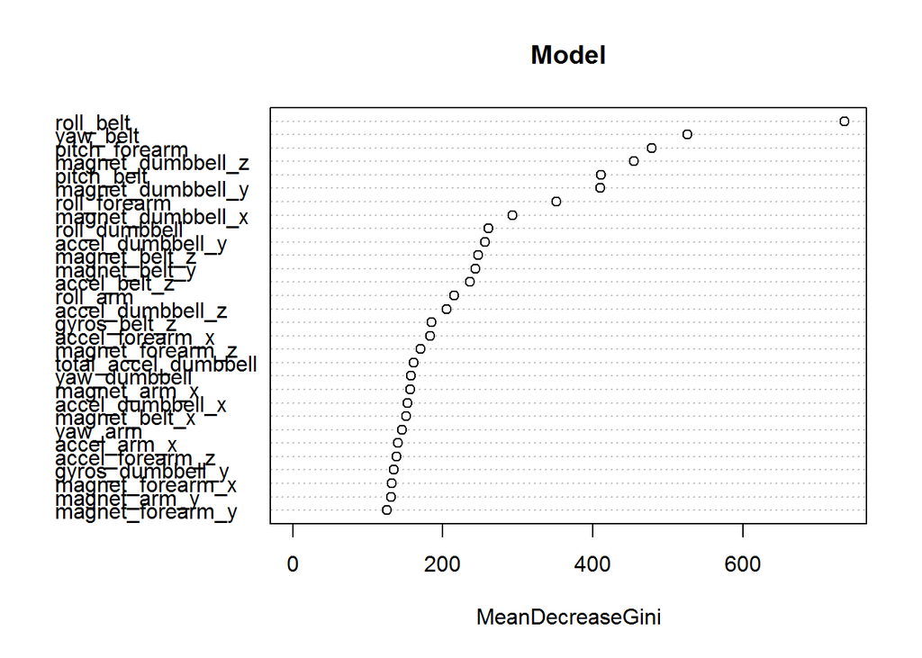

```r
Model <- randomForest(classe~., data=TrainingSet1, method='class')
# This creates a 25.5 MB data set and needs atleast 1 GB of free memory for execution.
varImpPlot(Model,)
```

## Cross validation of model

The model is now tested against TrainingSet2, this set hasn’t been manipulated in any way so should give an reliable accurancy estimate.

```r
# Using confusionMatrix to test the accuracy of the model
pred = predict(Model,TrainingSet2,type='class')
CM=confusionMatrix(pred,TrainingSet2$classe)
CM
```

```
## Confusion Matrix and Statistics
##
##           Reference
## Prediction    A    B    C    D    E
##          A 2231    8    0    0    0
##          B    1 1508   15    0    0
##          C    0    2 1353   17    5
##          D    0    0    0 1269    6
##          E    0    0    0    0 1431
##
## Overall Statistics
##
##                Accuracy : 0.9931
##                  95% CI : (0.991, 0.9948)
##     No Information Rate : 0.2845
##     P-Value [Acc > NIR] : < 2.2e-16
##
##                   Kappa : 0.9913
##  Mcnemar's Test P-Value : NA
##
## Statistics by Class:
##
##                      Class: A Class: B Class: C Class: D Class: E
## Sensitivity            0.9996   0.9934   0.9890   0.9868   0.9924
## Specificity            0.9986   0.9975   0.9963   0.9991   1.0000
## Pos Pred Value         0.9964   0.9895   0.9826   0.9953   1.0000
## Neg Pred Value         0.9998   0.9984   0.9977   0.9974   0.9983
## Prevalence             0.2845   0.1935   0.1744   0.1639   0.1838
## Detection Rate         0.2843   0.1922   0.1724   0.1617   0.1824
## Detection Prevalence   0.2854   0.1942   0.1755   0.1625   0.1824
## Balanced Accuracy      0.9991   0.9954   0.9927   0.9929   0.9962
```

The model has an accuracy of **99.31%** which validates the model.

## Out of Sample error rate

We need to calculate the out of sample error rate of the model. [Function Design from Stackoverflow.com](http://stackoverflow.com/questions/15213260/how-to-fit-a-model-i-built-to-another-data-set-and-get-residuals)

```r
missed <- function(values, predicted) {
  sum(predicted != values) / length(values)
}
SampleErrorRate <- missed(TrainingSet2$classe, pred)
SampleErrorRate
```

```
## [1] 0.006882488
```

The out of sample error rate of the model is **0.69%**

## Conclusion

Using the model to submit predictions of testing data for Assignment Submission. [Function Design from Assignment Submission : instructions](https://class.coursera.org/predmachlearn-032/assignment/view?assignment_id=5)

```r
answers <- predict(Model, testing)
pml_write_files = function(x){
  n = length(x)
  for(i in 1:n){
    filename = paste0("problem_id_",i,".txt")
    write.table(x[i],file=filename,quote=FALSE,row.names=FALSE,col.names=FALSE)
  }
}
pml_write_files(answers)
```